# Simulation with sample data

## This week in tgs data science

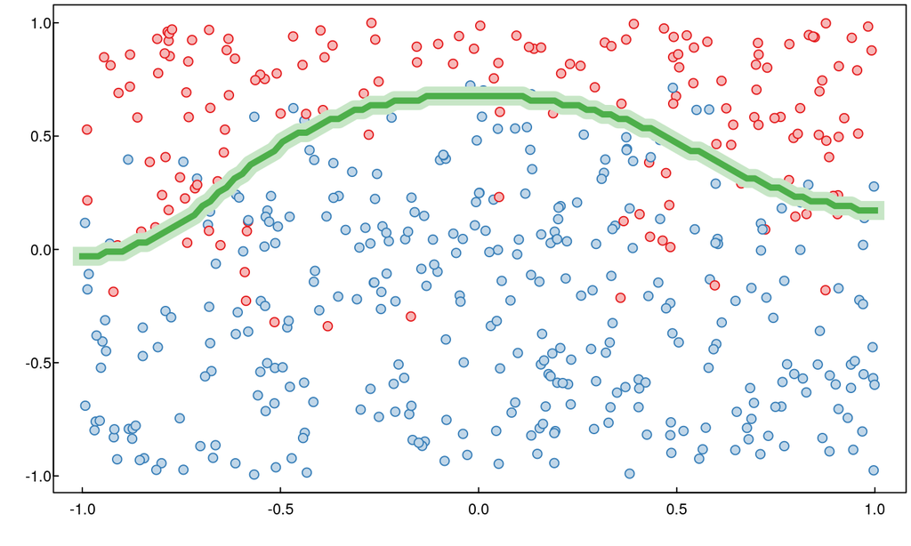

## Sampling distribution

\[\text{Recall } \boldsymbol{X}_N = X_1, X_2, \ldots, X_N\]

\(\boldsymbol{X}_N\) is our notation for a series of measures from a sample of size \(N\).

## Sampling distribution

If the measure of interest is \[X = \text{HbA1C,}\] then \[\boldsymbol{X}_{134}\] is HbA1C measurements from a sample of 134 individuals.

## Sampling distribution

We’ve been focused on a number of different transformations of the sample, \(\boldsymbol{X}_{N}\):

| Transformation | Formula |
| --- | --- |
| Mean | \(\bar{X} = \frac{1}{N}\sum_{i=1}^N X_i\) |
| Median | \(X_{((N+1)/2)}\) |
| Variance | \(s^2 = \frac{1}{N-1}\sum_{i=1}^N (X_i - \bar{X})^2\) |
| Min | \(X_{(1)}\) |
| Max | \(X_{(N)}\) |

## Sampling distribution

The **sampling distribution** is the distribution of the descriptive summaries from the sample.

\[\text{If } X_i\sim F_X(x), \text{ then } g(\boldsymbol{X}_N) \sim \text{Sampling distribution}\]

## Sampling distribution

| Transformation | Formula | Sampling distribution |
| --- | --- | --- |
| Mean | \(\bar{X} = \frac{1}{N}\sum_{i=1}^N X_i\) | (Hold your horses, we’ll get there.) |
| Median | \(X_{((N+1)/2)}\) | `porder`, `dorder` |
| Variance | \(s^2 = \frac{1}{N-1}\sum_{i=1}^N (X_i - \bar{X})^2\) |  |
| Min | \(X_{(1)}\) | `porder`, `dorder` |
| Max | \(X_{(N)}\) | `porder`, `dorder` |

## Sampling distribution

| Transformation | Formula | Analytic | Simulation |
| --- | --- | --- | --- |
| Mean | \(\bar{X} = \frac{1}{N}\sum_{i=1}^N X_i\) |  |  |
| Median | \(X_{((N+1)/2)}\) | `porder`, `dorder` |  |
| Variance | \(s^2 = \frac{1}{N-1}\sum_{i=1}^N (X_i - \bar{X})^2\) |  |  |
| Min | \(X_{(1)}\) | `porder`, `dorder` |  |
| Max | \(X_{(N)}\) | `porder`, `dorder` |  |

## Example 1: Crazy mixture distribution

```r
rf3 <- function(N){
  G <- sample(0:2, N, replace = TRUE, prob = c(5,3,2))
  (G==0)*rnorm(N) + (G==1)*rnorm(N,4) + (G==2)*rnorm(N,-4,2)
}

pf3 <- function(x){
  .5*pnorm(x) + .3*pnorm(x,4) + .2*pnorm(x,-4,2)
}

df3 <- function(x){
  .5*dnorm(x) + .3*dnorm(x,4) + .2*dnorm(x,-4,2)
}
```

## Example 1: Crazy mixture distribution

```r
par(mfrow = c(1, 2))
curve(pf3(x), -10, 9, lwd = 3, col = "blue", ylab = "Probability")
curve(df3(x), -10, 9, lwd = 3, col = "darkgreen", ylab = "Density")
```

## Example 1: Crazy mixture distribution

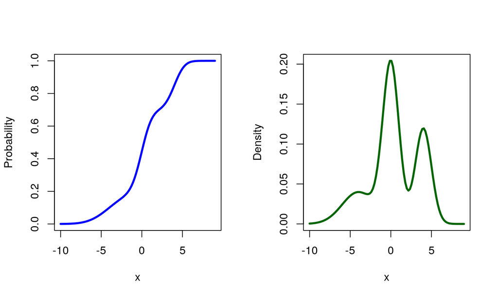

## Example 1: Crazy mixture distribution

### Sampling distribution of the variance via simulation

```r
N <- 134
M <- 5000
X <- array(rf3(N*M), dim = c(M,N))
vars <- apply(X, 1, var)
par(mfrow = c(1,2))
plot(ecdf(vars), main = "ECDF")
hist(
    vars
  , breaks = 50
  , main = "EPDF"
  , freq = FALSE
  , border = "white"
  , col = "gray50"
  , xlab = "x"
)
box()
```

## Example 1: Crazy mixture distribution

### Sampling distribution of the variance via simulation

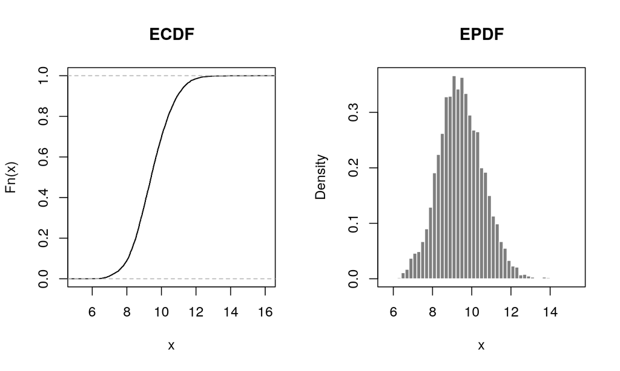

## Example 2: System failure time

### Recall, the distribution for system failure time for the parallel design was the sampling distribution of the max

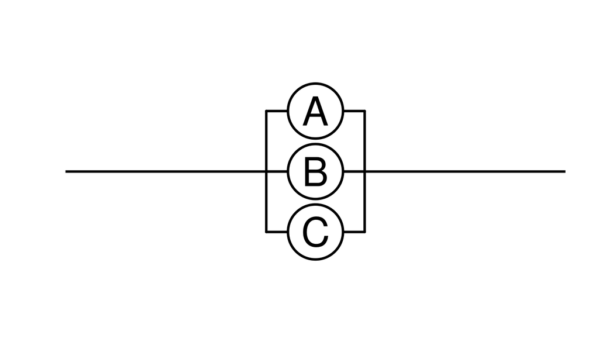

## Example 2: System failure time

### Recall, the distribution for system failure time for the parallel design was the sampling distribution of the max, which we calculated via simulation

```r
N <- 3
M <- 5000
results <- rweibull(N*M, shape = 1.3, scale = 2) %>%
  array(dim = c(M, N)) %>%
  apply(1, max) %>%
  data.frame(sft = .)
```

## Example 2: System failure time

### Plot of simulated sampling distribution

```r
suppressPackageStartupMessages(require(ggplot2))
results %>%
  ggplot() +
  aes(x = sft, y = stat(density)) +
  geom_histogram(bins = 50) +
  theme_minimal() +
  xlab("System failure time") +
  ylab("Density")
```

## Example 2: System failure time

### Plot of simulated sampling distribution

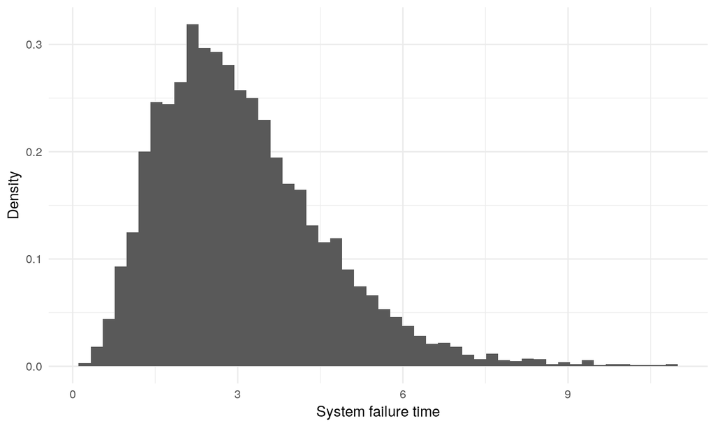

## Sampling distribution

If we know the underlying distribution of the data and we can sample from it, then we can use simulation to uncover the **sampling distribution**.

\[\text{If we can sample from } F_X(x), \text{ then we can uncover } g(\boldsymbol{X}_N)\]

## Reality check: Usually \(F_X(x)\) is unknown.

## Reality check: We only have a single sample, \(\boldsymbol{X}_N\)

## Sampling distribution

### Example: Glycohemoglobin from NHANES

| id | gh | age | sex |
| --- | --- | --- | --- |
| 1 | 5.2 | 34.2 | male |
| 2 | 5.7 | 16.8 | male |
| 3 | 6 | 60.2 | female |
| 4 | 5.1 | 26.1 | male |
| 5 | 5.3 | 49.7 | female |
| … | … | … | … |

## Sampling distribution from a single sample

To uncover the sampling distribution from a single sample, we are going to simulate from the sample. This tool is known as the **bootstrap**.

## Bootstrap

**Basic Idea:** Create new samples of size \(N\) by sampling rows with replacement.

## Bootstrap

### Example: Glycohemoglobin from NHANES

| id | gh | age | sex |
| --- | --- | --- | --- |
| 891 | 4.7 | 42.4 | male |
| 6222 | 6.7 | 60.9 | female |
| 615 | 5.8 | 65.7 | male |
| 615 | 5.8 | 65.7 | male |
| 6431 | 4.7 | 43.7 | female |
| … | … | … | … |

## Bootstrap

### Example: Glycohemoglobin from NHANES

**Note** that some rows may be selected multiple times.

| id | gh | age | sex |
| --- | --- | --- | --- |
| 891 | 4.7 | 42.4 | male |
| 6222 | 6.7 | 60.9 | female |
| 615 | 5.8 | 65.7 | male |
| 615 | 5.8 | 65.7 | male |
| 6431 | 4.7 | 43.7 | female |
| … | … | … | … |

## Bootstrap

### Example: Glycohemoglobin from NHANES

**Note** that some rows may not be selected at all.

| id | gh | age | sex |
| --- | --- | --- | --- |
| 891 | 4.7 | 42.4 | male |
| 6222 | 6.7 | 60.9 | female |
| 615 | 5.8 | 65.7 | male |
| 615 | 5.8 | 65.7 | male |
| 6431 | 4.7 | 43.7 | female |
| … | … | … | … |

## Boostrap

A new sample generated in this way is often called a **bootstrap sample** or **bootstrap replicate**.

## Boostrap

A new sample generated in this way is often called a **bootstrap sample** or **bootstrap replicate**.

A summary measure can be calculated for each bootstrap sample, like the variance or the mean.

## Boostrap

A new sample generated in this way is often called a **bootstrap sample** or **bootstrap replicate**.

A summary measure can be calculated for each bootstrap sample, like the variance or the mean.

The distribution of the summary measures calculated on bootstrap samples is called the **bootstrap distribution**.

## Bootstrap

There are bootstrap specific tools in R. For discussion and demonstration purposes, we are going to bootstrap by “hand”.

### Example: Bootstrap distribution of the variance of gh

```r
Hmisc::getHdata(nhgh) #loads nhgh, the NHANES data
gh <- nhgh$gh
n_gh <- length(gh)
M <- 5000
out <- rep(NA, M)
for(i in 1:M){
  index <- sample.int(n_gh, n_gh, replace = TRUE)
  out[i] <- gh[index] %>% var
}
```

## Bootstrap

### Example: Bootstrap distribution of the variance of gh

```r
par(mfrow = c(1,2))
plot(ecdf(out), lwd = 3, main = "ECDF")
hist(
    out
  , main = "EPDF"
  , ylab = "Density"
  , xlab = "Bootstrap variances"
  , breaks = 50
  , freq = FALSE
  , border = "white"
  , col = "gray50"
)
box()
```

## Bootstrap

### Example: Bootstrap distribution of the variance of gh

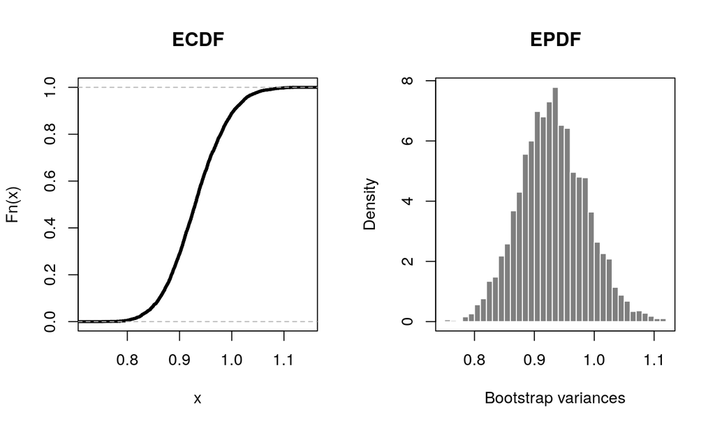

## Bootstrap

### **5 min example:** Bootstrap distribution of the gh

Generate the bootstrap distribution of the variance of \(Y\), which is defined as

\[Y = \left[1 - (\text{gh} + 4)^{-6}\right]\times 10^{11/6} - 10^{11/6}.\]

Create a plot of the ECDF and EPDF.

```r
Hmisc::getHdata(nhgh)
```

## Bootstrap

### **5 min example:** Bootstrap distribution of the gh

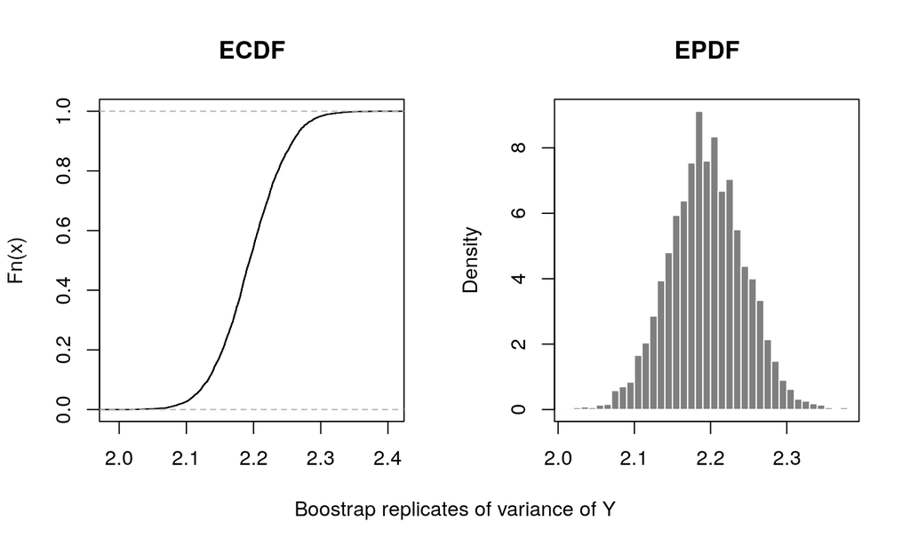

## Big picture

[figure not shown]

## Word of caution

There is nuance to the bootstrap which we will cover in coming days.